# Tutorial: Causal Modeling in EDM

2024-07-14

## A Motivating Case

You have a university course X and you are trying to understand why students fail this course. Ideally, you would love to know how you can help students in danger of failing.

You try Machine Learning (ML) to predict who will fail a course X. Your model does okay. You could use some kind of eXplainable AI now.

## A Motivating Case

SHAP tells you this:

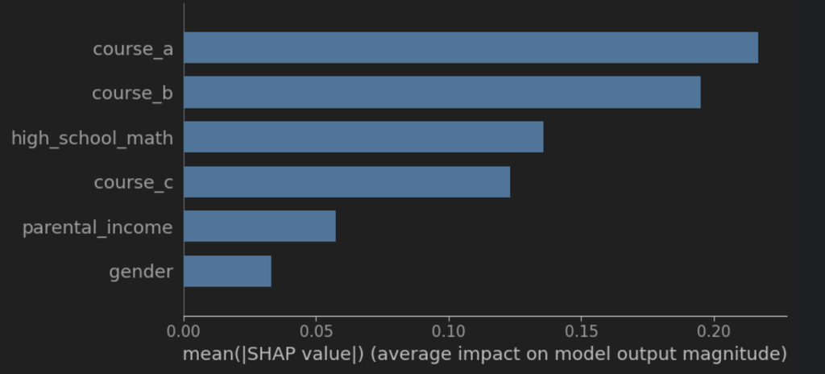

How would you interpret the results? Do you have any questions?

## A Motivating Case

A bunch questions arise:

- Why and how is course A relevant for course X?
- Does this mean that students should take courses A, B, and C before taking X?
- How is high school math related to this?
- Why do parental income and gender matter? Is there a fairness problem?

## A Motivating Case

Even when you use eXplainable AI (which is great already) this does not help you with answering all the questions we have.

Most questions that we have start with *Why?* or *How?*. Those are causal questions.

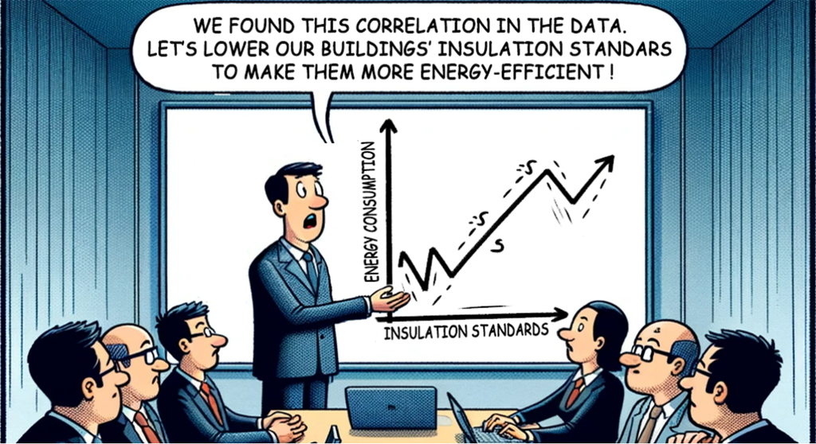

## Causal Questions Can Be Answered with Causal Models

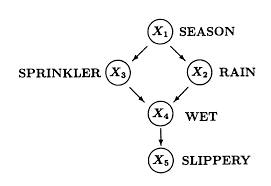

## Causal Modeling

Causal Modeling allows us to:

- make assumptions explicit
- answer causal questions
- estimate effect sizes from non-experimental data
- create testable hypothesis and make causal inferences
- avoid wrong conclusions
- consider fairness aspects
- explain data and models generating trust

## Agenda

Today, we will do the following:

- We will talk about causality and causal models. This includes a brief introduction to Bayesian Networks and Directed Acyclic Graphs (DAGs).
  - First phase until 9:45 am – mini break
- We will discuss how to model causal networks based on background knowledge and you will be given the task to construct a network. We will also see what information we can extract from them.
  - Second phase until 10:30 am – refreshment break
- We will discuss your results and how to model causal networks based on data (and based on data + background knowledge) and you will be given the task to learn a network.
  - Third phase until 12:25 pm

## Goals

After today, I hope you can answer:

- why causal modeling is interesting for EDM and what we can learn from causal models
- how we can construct causal models (on a high level)
- what advantages and disadvantages of different modeling options are

## Introduction

Who am I? My name is Lea Cohausz.

- PhD student at the chair of AI, University of Mannheim
- wrote a few papers making explicit use of causal models in one way or another (two under review currently)
- to learn more about me, visit my website (https://lea-cohausz.github.io/aboutme/)
- I’m also a co-organizer of the HEXED workshop (you should go there later)

[figure not shown]

## Causality and Causal Modeling

“Causality is an influence by which one event, process, state, or object (a cause) contributes to the production of another event, process, state, or object (an effect) where the cause is partly responsible for the effect, and the effect is partly dependent on the cause.” (Wikipedia)

“Causal models are mathematical models representing causal relationships within an individual system or population. They facilitate inferences about causal relationships from statistical data.” (Stanford Encyclopedia of Philosophy)

- difficult topic with different perspectives, pure association is not meant by it

## Causality

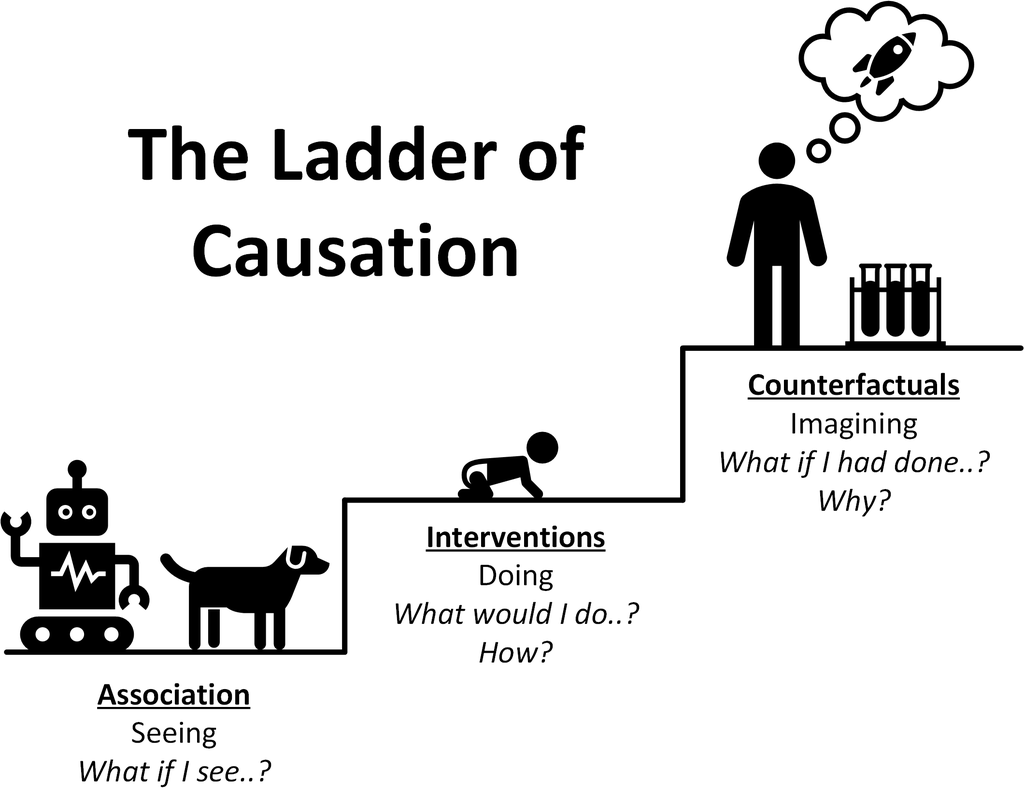

## Causal Models

Causal relationships can be represented by causal graphs. These are directed graphs with nodes or vertices representing variables and edges representing causal relationships.

- \(A \rightarrow B\): \(A\) influences \(B\)

Usually, we use Directed Acyclic Graphs (DAGs) or Bayesian Networks (BNs) for causal graphs. (Note: The graphical part of a BN is a DAG.)

- well suited because causality implies a temporal ordering

## DAGs

DAGs encode independence relationships

- the probability of X is fully determined by its parents: \(P(X) = \prod P(X|Pa(X))\)
- variables can be dependent on each other \(A \not \perp B\), independent \(A \perp B\), or conditionally independent \(A \perp B | C\)

## Structures in DAGs

- Chain: \(A \rightarrow B \rightarrow C\)
  - \(A \perp C | B\), \(B\) is a mediator
- Fork: \(A \leftarrow B \rightarrow C\)
  - \(A \perp C | B\) (same as chain!), \(B\) is a confounder
- Collider: \(A \rightarrow B \leftarrow C\)
  - \(A \perp C\) but \(A \not \perp C | B\)

Chains and forks have the same independence properties; statistics alone does not help with determining which is the case.

## Estimating Causal Effects

To estimate a causal effect from \(X\) on \(Y\), we need to control for all confounders. We can estimate the causal effect if the backdoor or frontdoor criterion is fulfilled.

Backdoor criterion: for a pair of nodes \(X,Y\), a set of nodes \(\mathbf{Z}\) satisfies the backdoor criterion if

- no node in \(\mathbf{Z}\) is a descendant of \(X\) and
- \(\mathbf{Z}\) blocks every path between \(X\) and \(Y\) that contains arrows into \(X\)

Then, we can estimate the causal effect using: \(P(Y|X) = \sum_Z P(Y|X,Z)P(Z)\)

## Estimating Causal Effects

To estimate a causal effect from \(X\) on \(Y\), we need to control for all confounders. We can estimate the causal effect if the backdoor or frontdoor criterion is fulfilled.

Frontdoor criterion: for a pair of nodes \(X,Y\), a set of nodes \(\mathbf{Z}\) satisfies the frontdoor criterion if

- \(\mathbf{Z}\) inercepts all nodes from \(X\) to \(Y\)
- there is no unblocked backdoor path from X to \(\mathbf{Z}\)
- all backdoor path from \(\mathbf{Z}\) to \(Y\) are blocked by \(X\)

Then, we can estimate the causal effect using: \(P(Y|X) = \sum_z P(Z|X)\sum_X P(Y|X,Z)P(X)\)

## Causal Graphs

Causal graphs do no just exist, we need to construct them.

- expert knowledge
- data-driven structure learning
- combination of data-driven and expert structure learning

## Causal Graphs: Expert Knowledge

Expert knowledge

- advantages:
  - valuable information from experts can be included
  - common knowledge can be included
  - full control
- disadvantages:
  - we don’t know the relationships for all variables
  - in particular in unfamiliar, poorly researched, or new settings
  - our assumptions may be wrong

## Causal Graphs: Data-Driven Structure Learning

Data-driven structure learning

- advantages:
  - detects statistical relationships and their absence
  - uncovers unknown connections
- disadvantages:
  - struggles with latent variables
  - struggles datasets with few instances and many variables
  - causality cannot be established by statistics alone

## Causal Graphs: Combining Data-Driven and Expert-Driven Structure Learning

Data-driven and expert-driven structure learning

- advantages:
  - best of both worlds
- disadvantages:
  - still somewhat tedious
  - poorly researched
  - not many straightforward implementations

## Constructing Graphs Using Expert Knowledge

DAGitty allows you to manually construct DAGs. https://www.dagitty.net/dags.html#

- you can do it in R or you can use the Web Interface
- it immediately tells you about the independence relationships in your causal model
- it also tells you which variables you need to control for if you want to estimate the effect from one variable on another

## Exercise

You talk to a study advisor of your university about the results of your ML model. She tells you: *“According to our curriculum, courses A and B teach you relevant knowledge for course X - that’s probably why they are important for passing X. These two courses are also quite study intense. I always notice that people whose parents are less well off financially have to work more and, thus, have less time to study. This isn’t really an issue for courses C and X, though. Also, I think for courses C, A, and X you just have to have certain aptitude for math. Between you and me, I’ve kind of suspected for a while that Prof. McJerk who teaches course A discriminates against women.”*

1. Try to model the situation in a DAG using DAGitty.
2. Which variables are (conditionally) independent of course X?
3. Can you estimate the effect of passing course A (course B) on passing course X? What would happen, if you cannot observe relevant knowledge directly?

## My Solution

https://dagitty.net/md792WyLM

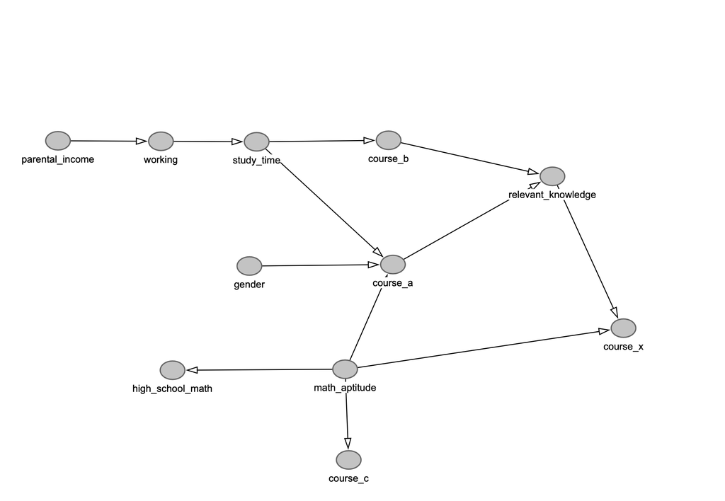

## My Solution

Conditionally independent of X are:

## My Solution

To estimate the effect of course a, adjust:

- course_b, math_aptitude or
- math_aptitude, study_time

To estimate the effect of course b, adjust:

- course_a, math_aptitude
- study_time

## Data-Driven Structure Learning

There are two (main) ways to perform data-driven structure learning: constraint-based and score-based (technically, there are also functional causal modeling and hybrid modeling).

Many different algorithms and implementations of these two families of structure learning approaches exist.

We will discuss the basics for each of the approaches.

## Constraint-Based Structure Learning

Constraint-based structure learning consists of two parts:

- independence tests to construct a skeleton and
- edge orientation

## Constraint-Based Structure Learning: Independence Tests

For each pair of variables \((x_i,x_j)\), conditional independence tests are performed with an increasing number of variables in the so-called separating set (i.e., the variables you condition on). We start with a fully connected but unoriented graph.

- First, we check whether \(x_i\) and \(x_j\) are fully independent. If they are, the empty separating set is stored, we remove the edge between \(x_i\) and \(x_j\), and we stop.

## Constraint-Based Structure Learning: Independence Tests

- First, we check whether \(x_i\) and \(x_j\) are fully independent. If they are, the empty separating set is stored, we remove the edge between \(x_i\) and \(x_j\), and we stop.
- If they are not, we check for each other variable in the graph \(x_k \neq x_i, x_j\) whether this variable makes the two conditionally independent. If it does, the separating set contains this variable, we remove the edge between \(x_i\) and \(x_j\), and we stop. Note: to avoid artefacts of node ordering, many algorithms run until all single variables are checked and use all resulting separating sets for further steps.
- If it does not, we continue with two variables and so on…
- Until we are left with a skeleton of dependent variables.

## Constraint-Based Structure Learning: Edge Orientation

Now, as many edges as possible are oriented. This is done by looking at three variables connected by two edges step-by-step.

As already mentioned, while we cannot distinguish between \(x_i \rightarrow x_k \rightarrow x_j\) and \(x_i \leftarrow x_k \rightarrow x_j\) from independence tests alone, we can distinguish \(x_i \rightarrow x_k \leftarrow x_j\) from the others. If \(x_k\) is not in the separating set of \((x_i, x_j)\), we know that we have a so-called v-structure.

All of the identified v-structures are oriented accordingly.

Subsequently, other edges are oriented in a way to avoid new v-structures.

## Constraint-Based Structure Learning: Edge Orientation

Not all edges are oriented using this procedure. What we get is a Complete Partially Directed Acyclic Graph (CPDAG).

All DAGs constructed from this CPDAG are part of the same Markov Equivalence Class and statistically indistinguishable.

## Constraint-Based Structure Learning

Advantages:

- if the independence tests are correct, the resulting CPDAG is guaranteed to be correct
- few incorrect edge insertions

Disadvantages:

- usually misses some edges because non-linear relationships are not detected
- difficult to adjust to include human background knowledge

## Score-Based Structure Learning

We select some kind of scoring function, such as the Bayesian Information Criterion. We start with a completely unconnected graph.

Iteratively, edges are added and deleted so that the increase to the score is maximized until the increase is below a certain specified threshold. Different algorithms employ different heuristics to explore the search space efficiently.

## Score-Based Structure Learning

Advantages:

- usually leads to good results
- easy to include background knowledge

Disadvantages:

- no guarantee to get the best result - might get stuck in local maxima
- no guarantee to get correct result

## An R Package for Structure Learning

R offers a great package to (among other things) perform structure learning: *bnlearn*

Load the prepared data. It fits the scenario we dicsussed already.

```r
library(bnlearn)
data <- read.csv("data_for_the_tutorial.csv")
data <- as.data.frame(unclass(data),stringsAsFactors=TRUE)
```

## Constraint-Based Structure Learning

The PC-Stable algorithm is one of the most consistent constraint-based structure learning algorithms.

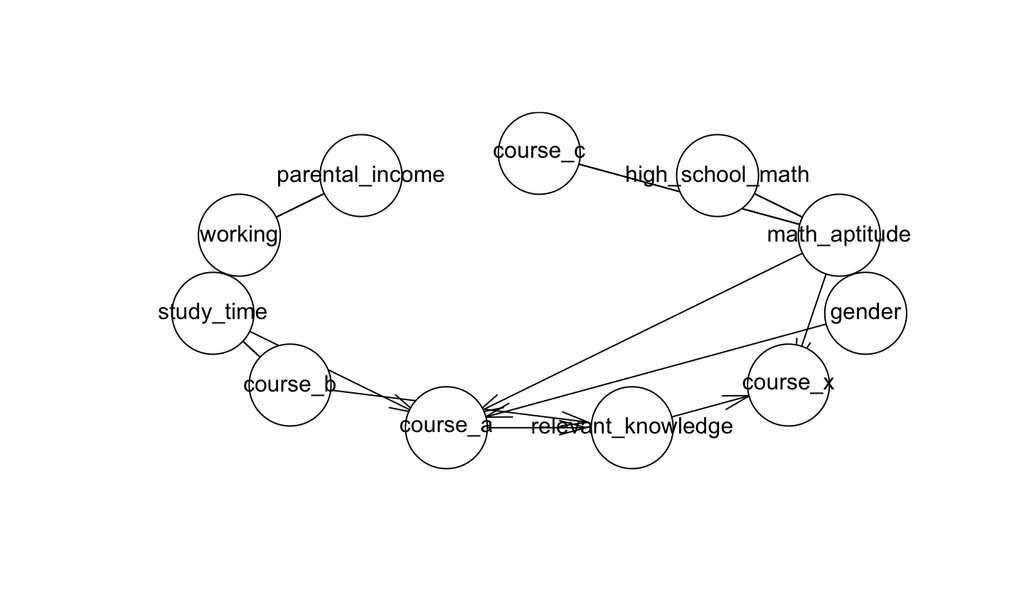

```r
bn.pc <- pc.stable(data)
plot(bn.pc)
```

## Constraint-Based Structure Learning

- all edges are correct
- but not all are oriented
- those that are oriented, are correct

## Score-Based Structure Learning

The Hill-Climber algorithm is, despite its simplicity, a very well working algorithm.

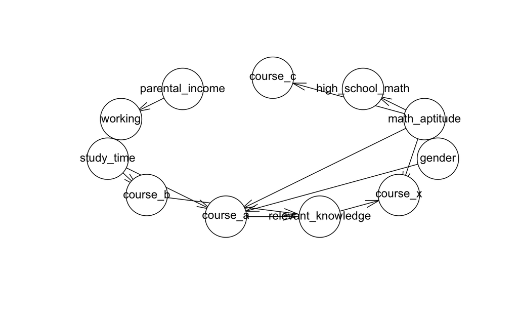

```r
bn.hc <- hc(data, score = "bic")
plot(bn.hc)
```

## Score-Based Structure Learning

- all edges are correct and correctly oriented

## When Things Are Less Optimal

When the relationships between variables aren’t quite defined as well and we have a small dataset…

… the algorithms won’t do this good.

This is also the case when we do not have some variables. For example, let’s say we don’t know students’ math aptitude.

## Not Having Data For A Variable

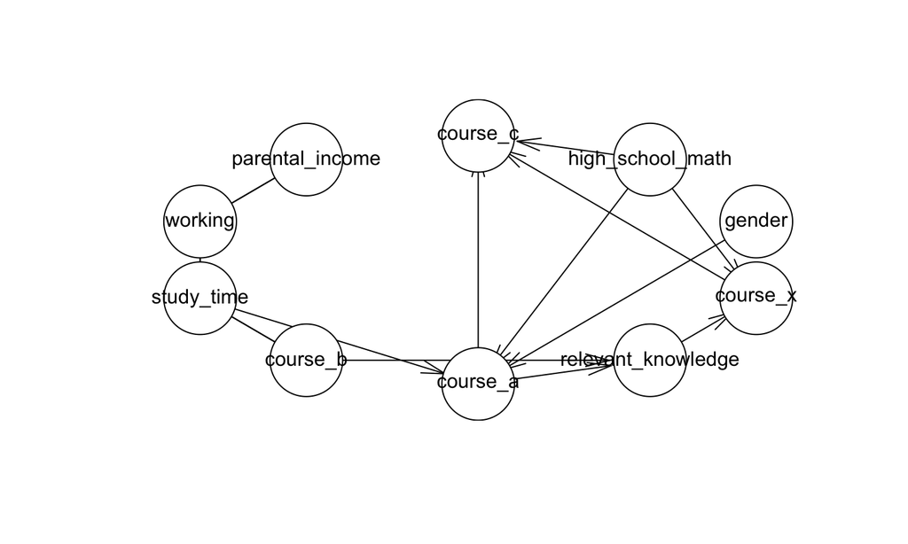

```r
data$math_aptitude <- NULL
bn.pc <- pc.stable(data)
plot(bn.pc)
```

## Not Having Data For A Variable

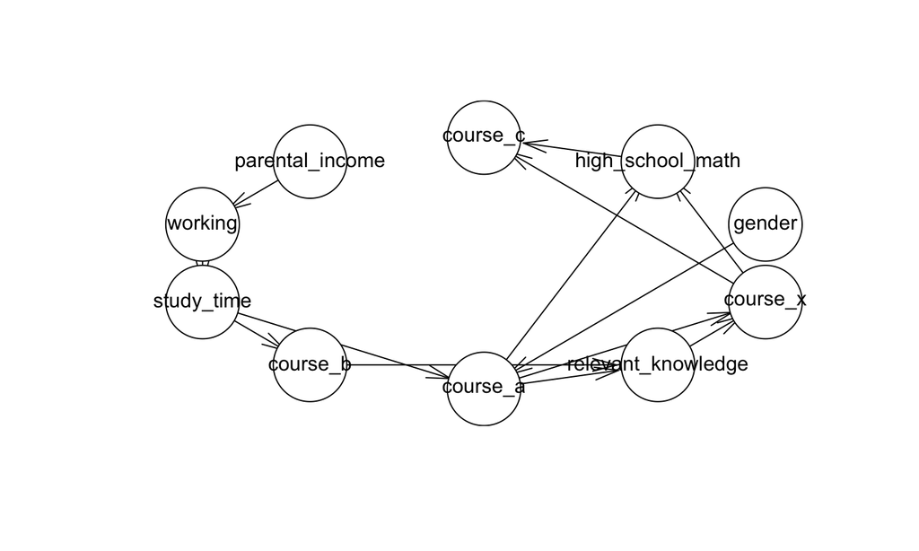

```r
bn.hc <- hc(data)
plot(bn.hc)
```

## Not Having Data For A Variable

Now, high school math and course c are connected to other variables.

What would be the “right” way to deal with this?

- we can specify background knowledge, e.g., temporally, it makes no sense that course a can influence high school math

Experiment with the argument *blacklist*. Hint: use a dataframe with columns “FROM” and “TO” to specify which relationships are not allowed.

## Background Knowledge

```r
black_data <- data.frame(
    FROM = c("course_c", "course_x", "course_a",
             "course_x", "course_b", "course_a"),
    TO = c("high_school_math", "high_school_math",
           "high_school_math", "course_c", "gender",
           "gender"),
    stringsAsFactors = FALSE
)
```

## Background Knowledge

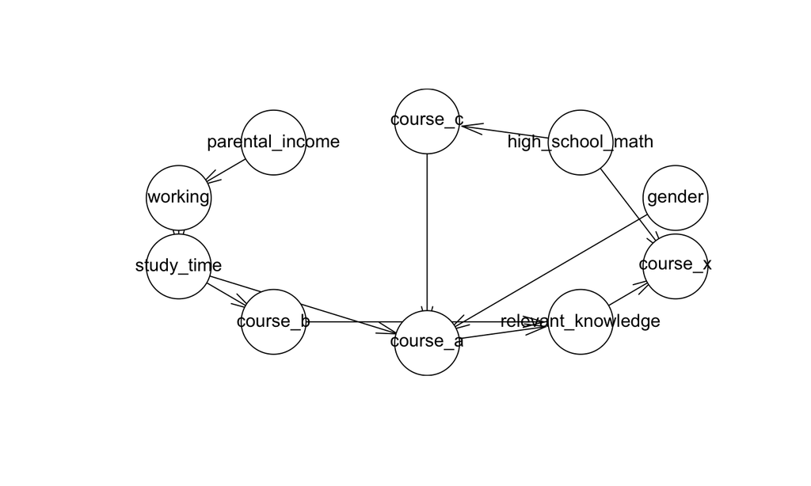

```r
bn.hc <- hc(data, blacklist = black_data)
plot(bn.hc)
```

## Background Knowledge: Remarks

- using background knowledge is helpful
- but if important variables are missing, it can lead to weird effects on other relationships, too
- regardless, the problem remains that the learned relationships do not necessarily encode real causal relationships

## Background Knowledge

If you are certain that a latent variable is important, you can also manually alter the DAG after structure learning.

Here, you could add the node and change the edges.

Note: You will not get useful Conditional Probability Tables then.

## Structure Learning in Education

In education, we often have a lot of background knowledge:

- temporal: socio-demographic variables are not influenced by grades or activity, certain classes or exercises are done in a specific order
- latent: a program’s curriculum provides information on which latent variables may be important for what classes

## Causal Modeling in Education

What can we do now with our DAGs?

- we have a better understanding of the data
- we can provide better interventions
  - we do not give “wrong” advice (e.g., to first take course c)
  - we can investigate the effects of our interventions
- we can spot potential fairness concerns resulting from applying ML on the data (e.g., our model may learn that one gender performs better) [Advertisement]

## Causal Modeling in Education

However, we should also be careful:

- does our data translate well to our setting?
- do we have all variables we need?
- if not, can we include the latent variables?
- how confident are we in how the latent variables are connected?
- is a relationship a real relationship or just an artefact?

## What did we do today

- we discussed the basics of DAGs and Bayesian Networks
- we discussed how to construct DAGs using expert knowledge, data, and both
- we discussed why DAGs are important for EDM (and what their shortcomings are)

## Closing Remarks

Causal Modeling can be tricky and requires effort but is a helpful tool in many ways.

If you want to use causal modeling but need some more help or have some questions, feel free to reach out via email.

**Thanks a lot for your attention!**